# Linear Analysis

Tom Kincaid

2020-09-17

## Preliminaries

This document presents analysis of a GRTS survey design for a linear resource. The linear resource used in the analysis is streams in the Upper Wabash basin in Indiana. The analysis will include calculation of three types of population estimates: (1) estimation of proportion and size (length of streams) for site evaluation status categorical variables; (2) estimation of proportion and size for stream condition categorical variables; and (3) estimation of the cumulative distribution function (CDF) and percentiles for quantitative variables. Testing for difference between CDFs from subpopulations also will be presented.

The initial step is to use the `library` function to load the `spsurvey` package. After the package is loaded, a message is printed to the R console indicating that the `spsurvey` package was loaded successfully.

Load the `spsurvey` package:

```r
library(spsurvey)
```

### Load the survey design and analytical variables data set

The next step is to load the data set, which includes both survey design variables and analytical variables. The data function is used to load the data set and assign it to a data frame named `IN_streams`. The `nrow` function is used to determine the number of rows in the `IN_streams` data frame, and the resulting value is assigned to an object named `nr`. Finally, the initial six lines and the final six lines in the `IN_streams` data frame are printed using the `head` and `tail` functions, respectively.

Load the survey design and analytical variables data set:

```r
data(IN_streams)
nr <- nrow(IN_streams)
```

Display the initial six lines in the data file:

```r
head(IN_streams)
```

```
#>       siteID  xcoord   ycoord       wgt Strahler_Cat           Status    TNT
#> 1 INRB98-001 7574790 12556023 180.49965          1st Landowner_Denial Target
#> 2 INRB98-002 7490591 12580092 180.49965          1st          Sampled Target
#> 3 INRB98-003 7500191 12545177  57.70535          2nd          Sampled Target
#> 4 INRB98-004 7543103 12557747  26.40031          4th Landowner_Denial Target
#> 5 INRB98-005 7459317 12689535  29.59298          3rd          Sampled Target
#> 6 INRB98-006 7515604 12649037  57.70535          2nd Physical_Barrier Target
#>   IBI_Score   IBI_Status QHEI_Score  QHEI_Status
#> 1        NA         <NA>         NA         <NA>
#> 2        50 Not_Impaired         48     Impaired
#> 3        22     Impaired         65 Not_Impaired
#> 4        NA         <NA>         NA         <NA>
#> 5        38 Not_Impaired         31     Impaired
#> 6        NA         <NA>         NA         <NA>
```

Display the final six lines in the data file:

```r
tail(IN_streams)
```

```
#>         siteID  xcoord   ycoord       wgt Strahler_Cat           Status
#> 95  INRB98-095 7503526 12628573  57.70535          2nd Landowner_Denial
#> 96  INRB98-096 7496050 12662272 180.49965          1st        NonTarget
#> 97  INRB98-097 7483750 12664829  29.59298          3rd   Chemistry_Only
#> 98  INRB98-098 7496653 12634435 180.49965          1st        NonTarget
#> 99  INRB98-099 7443579 12609765  26.40031          4th          Sampled
#> 100 INRB98-100 7445529 12651391  26.40031          4th   Chemistry_Only
#>           TNT IBI_Score   IBI_Status QHEI_Score  QHEI_Status
#> 95     Target        NA         <NA>         NA         <NA>
#> 96  NonTarget        NA         <NA>         NA         <NA>
#> 97     Target        NA         <NA>         NA         <NA>
#> 98  NonTarget        NA         <NA>         NA         <NA>
#> 99     Target        48 Not_Impaired         78 Not_Impaired
#> 100    Target        NA         <NA>         NA         <NA>
```

The sample of streams in Indiana is displayed in the figure below. The sample sites for each Strahler order are displayed using a unique color.

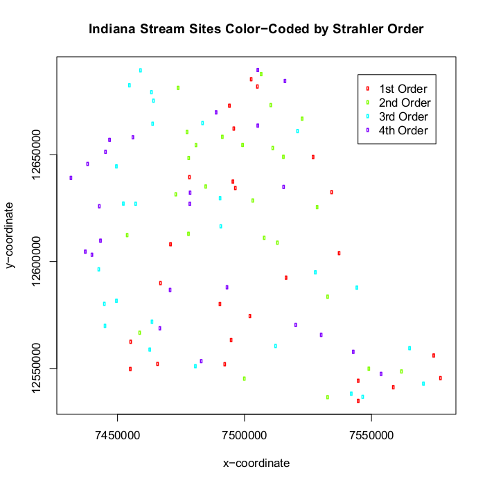

Location of stream sample sites in Indiana color-coded by Strahler order.

## Analysis of site status evaluation variables

The first analysis that will be examined is calculation of extent estimates for site status evaluation variables. Extent is measured both by the proportion of the resource in status evaluation categories and by size of the resource in each category. For a linear resource like streams, size refers to the length of streams in a category. For calculating extent estimates (and for all of the analyses we will consider), the survey design weights are incorporated into the calculation process. Weights used in the analyses were modified from the original survey design weights to ensure that the weights sum to the known size of the resource. Further information regarding weight adjustment is provided in the help page for the `adjwgt` (weight adjustment) function. Two site status variables will be examined: (1) status, which classifies streams into seven evaluation categories and (2) TNT, which classifies streams as either “Target” or “NonTarget”. The `table` and `addmargins` functions are used to create tables displaying the count for each code (level) of the two status variables.

Use the `table` and `addmargins` functions to create a table displaying the count for each code of the status variable:

```r
cat("\nA table displaying the number of values for each level of the status
variable follows:\n")
```

```
#>
#> A table displaying the number of values for each level of the status
#> variable follows:
```

```r
addmargins(table(IN_streams$Status))
```

```
#>
#>     Chemistry_Only   Landowner_Denial          NonTarget   Physical_Barrier
#>                 14                 19                  9                  7
#>            Sampled Target_Not_Sampled            Unknown                Sum
#>                 48                  2                  1                100
```

Use the table and addmargins functions to create a table displaying the count for each code of the TNT variable

```r
cat("\nA table displaying the number of values for each level of the TNT
variable follows:\n")
```

```
#>
#> A table displaying the number of values for each level of the TNT
#> variable follows:
```

```r
addmargins(table(IN_streams$TNT))
```

```
#>
#> NonTarget    Target       Sum
#>        10        90       100
```

Conduct an analysis of site status evaluation variables. Create the sites data frame, which identifies sites to use in the analysis. Note that all sites will be used to estimate number of streams in each category:

```r
sites <- data.frame(siteID=IN_streams$siteID,
                    Use=rep(TRUE, nr))
```

Create the `subpop` data frame, which defines populations and subpopulations for which estimates are desired:

```r
subpop <- data.frame(siteID=IN_streams$siteID,
                     Upper_Wabash=rep("Upper Wabash", nr),
                                   Strahler_Order=IN_streams$Strahler_Cat)
```

```r
design <- data.frame(siteID=IN_streams$siteID,
                     wgt=IN_streams$wgt,
                     xcoord=IN_streams$xcoord,
                     ycoord=IN_streams$ycoord)
```

Create the `data.cat` data frame, which specifies the variables to use in the analysis

```r
data.cat <- data.frame(siteID=IN_streams$siteID,
                       Status=IN_streams$Status,
                       Target_NonTarget=IN_streams$TNT)
```

Use the `cat.analysis` function to calculate extent estimates for the site status evaluation variables:

```r
Extent_Estimates <- cat.analysis(sites, subpop, design, data.cat)
```

The extent estimates for all basins combined are displayed using the `print` function. The object produced by `cat.analysis` is a data frame containing thirteen columns. The first five columns identify the population (Type), subpopulation (Subpopulation), response variable (Indicator), levels of the response variable (Category), and number of values in a category (NResp). A category labeled “Total” is included for each combination of population, subpopulation, and response variable. The next four columns in the data frame provide results for the proportion (percent scale) estimates: the proportion estimate (Estimate.P), standard error of the estimate (StdError.P), lower confidence bound (LCB95Pct.P), and upper confidence bound (UCB95Pct.P). Argument conf for `cat.analysis` allows control of the confidence bound level. The default value for conf is 95, hence the column names for confidence bounds contain the value 95. Supplying a different value to the conf argument will be reflected in the confidence bound names. Confidence bounds are obtained using the standard error and the Normal distribution multiplier corresponding to the confidence level. The final four columns in the data frame provide results for the size (units scale) estimates: the size estimate (Estimate.U), standard error of the estimate (StdError.U), lower confidence bound (LCB95Pct.U), and upper confidence bound (UCB95Pct.U). Note that the size estimate for the Total category will be equal to the sum of the survey design weights.

Print the extent estimates for all basins combined:

```r
print(Extent_Estimates[c(1:8, 32:34),])
```

```
#>            Type Subpopulation        Indicator           Category NResp
#> 1  Upper_Wabash  Upper Wabash           Status     Chemistry_Only    14
#> 2  Upper_Wabash  Upper Wabash           Status   Landowner_Denial    19
#> 3  Upper_Wabash  Upper Wabash           Status          NonTarget     9
#> 4  Upper_Wabash  Upper Wabash           Status   Physical_Barrier     7
#> 5  Upper_Wabash  Upper Wabash           Status            Sampled    48
#> 6  Upper_Wabash  Upper Wabash           Status Target_Not_Sampled     2
#> 7  Upper_Wabash  Upper Wabash           Status            Unknown     1
#> 8  Upper_Wabash  Upper Wabash           Status              Total   100
#> 32 Upper_Wabash  Upper Wabash Target_NonTarget          NonTarget    10
#> 33 Upper_Wabash  Upper Wabash Target_NonTarget             Target    90
#> 34 Upper_Wabash  Upper Wabash Target_NonTarget              Total   100
#>     Estimate.P StdError.P  LCB95Pct.P  UCB95Pct.P Estimate.U StdError.U
#> 1    6.5597397  1.6598843   3.3064261   9.8130532  482.67548  110.03523
#> 2   17.8769326  3.7404140  10.5458559  25.2080092 1315.41150  285.35722
```

[output cut: 21 more lines]

The `write.csv` function is used to store the extent estimates as a comma-separated value (csv) file. Files in csv format can be read by programs such as Microsoft Excel.

Write results as a comma-separated value (csv) file:

```r
write.csv(Extent_Estimates, file="Extent_Estimates.csv", row.names=FALSE)
```

## Analysis of stream condition variables

The second analysis that will be examined is estimating resource proportion and size for stream condition variables. Two stream condition variables will be examined: (1) IBI_Status, which classifies streams by IBI (index of biotic integrity) status categories and (2) QHEI_Status, which classifies streams by QHEI (qualitative habitat evaluation index) status categories. The `table` and `addmargins` functions are used to create tables displaying the count for each level of the two stream condition variables.

Use the table and addmargins functions to create a table displaying the count for each code of the IBI status variable:

```r
cat("\nA table displaying the number of values for each level of the IBI status
variable follows:\n")
```

```
#>
#> A table displaying the number of values for each level of the IBI status
#> variable follows:
```

```r
addmargins(table(IN_streams$IBI_Status))
```

```
#>
#>     Impaired Not_Impaired          Sum
#>           12           36           48
```

Use the table and addmargins functions to create a table displaying the count for each code of the QHEI status variable

```r
cat("\nA table displaying the number of values for each level of the QHEI status
variable follows:\n")
```

```
#>
#> A table displaying the number of values for each level of the QHEI status
#> variable follows:
```

```r
addmargins(table(IN_streams$QHEI_Status))
```

```
#>
#>     Impaired Not_Impaired          Sum
#>           14           34           48
```

As for extent estimates, the `cat.analysis` function will be used to calculate condition estimates. The `sites` data frame for this analysis differs from the one used to calculate extent estimates. The Use logical variables in `sites` is set equal to the value “Sampled”, so that only sampled sites are used in the analysis. The `subpop` and `design` data frames created in the prior analysis can be reused for this analysis. The `data.cat` data frame contains the two stream condition variables: IBI_Status and QHEI_Status. Variables IBI_Status and QHEI_Status in the `IN_streams` data frame are assigned to IBI_Status and QHEI_Status, respectively.

Create the `sites` data frame

Conduct an analysis of stream condition variables. Create the `sites` data frame. Note that only sampled sites are used:

```r
sites <- data.frame(siteID=IN_streams$siteID,
                    Use=IN_streams$Status == "Sampled")
```

Create the `data.cat` data frame, which specifies the variables to use in the analysis:

```r
data.cat <- data.frame(siteID=IN_streams$siteID,
                       IBI_Status=IN_streams$IBI_Status,
                       QHEI_Status=IN_streams$QHEI_Status)
```

Use the `cat.analysis` function to calculate estimates for the stream condition variables:

```r
Condition_Estimates <- cat.analysis(sites, subpop, design, data.cat)
```

Print the condition estimates for all basins combined:

```r
print(Condition_Estimates[c(1:3, 16:18),])
```

```
#>            Type Subpopulation   Indicator     Category NResp Estimate.P
#> 1  Upper_Wabash  Upper Wabash  IBI_Status     Impaired    12   27.66052
#> 2  Upper_Wabash  Upper Wabash  IBI_Status Not_Impaired    36   72.33948
#> 3  Upper_Wabash  Upper Wabash  IBI_Status        Total    48  100.00000
#> 16 Upper_Wabash  Upper Wabash QHEI_Status     Impaired    14   40.90216
#> 17 Upper_Wabash  Upper Wabash QHEI_Status Not_Impaired    34   59.09784
#> 18 Upper_Wabash  Upper Wabash QHEI_Status        Total    48  100.00000
#>    StdError.P LCB95Pct.P UCB95Pct.P Estimate.U StdError.U LCB95Pct.U UCB95Pct.U
#> 1    6.611920   14.70139   40.61964    945.205   247.3122   460.4819   1429.928
#> 2    6.611920   59.38036   85.29861   2471.958   345.9131  1793.9811   3149.935
#> 3    0.000000  100.00000  100.00000   3417.163   362.5003  2706.6756   4127.651
#> 16   8.383366   24.47106   57.33325   1397.694   357.9031   696.2163   2099.171
#> 17   8.383366   42.66675   75.52894   2019.470   305.3225  1421.0486   2617.891
#> 18   0.000000  100.00000  100.00000   3417.163   362.5003  2706.6756   4127.651
```

Use the `write.csv` function to write the condition estimates as a csv file:

```r
write.csv(Condition_Estimates, file="Condition_Estimates.csv", row.names=FALSE)
```

## Analysis of stream condition variables correcting for population size

The frame is a data structure containing spatial location data in addition to other attributes regarding a resource of interest and is used to create a survey design. A frame often takes the form of a shapefile. The frame can be used to obtain size values (e.g., length of streams) for the populations and subpopulations examined in an analysis. Examination of the Estimates.U column in the `Condition_Estimates` data frame produced by `cat.analysis` reveals that the estimated Total value for both condition variables and each combination of population value and subpopulation value does not sum to the corresponding frame size value. For example, the Total entry in the Estimate.U column for the IBI_status variable, population “Upper_Wabash” and subpopulation “Upper Wabash” is 3,417 kilometers(rounded to a whole number). The corresponding frame size value is 7,358 kilometers. The popsize (population size) argument to `cat.analysis` provides a mechanism for forcing the size estimates to sum to a desired value, e.g., the frame size value. Note that including popsize as an argument results in assigning the popsize value to the Total category of the size estimates. Use of the popsize argument assumes that sites which were evaluated but not sampled were missing at random. The missing at random asumption may not be a valid assumption, e.g., sites for which access was denied by the landowner may not be the same as sites that were sampled. For the current analysis, we will assume that the assumption is valid. As a first step for use of the popsize argument, the `combine` function is used to create a named vector of frame size values for each basin. Output from the `combine` function is assigned to an object named `framesize`. The `popsize` argument is a list, which is a particular type of R object. The `popsize` list must include an entry for each population type included in the `subpop` data frame, i.e., Upper_Wabash and Strahler_Order for this analysis. The sum function applied to `framesize` is assigned to the Upper_Wabash entry in the `popsize` list. Recall that the Strahler order population type contains subpopulations, i.e., Strahler order categories. When a population type contains subpopulations, the entry in the `popsize` list also is a list. The `as.list` function is applied to `framesize`, and the result is assigned to the Strahler_Order entry in the `popsize` list.

```r
framesize <- c("1st"=4514.450, "2nd"=1443.260, "3rd"=740.146, "4th"=660.294)
```

Use the `cat.analysis` function to calculate estimates for the stream condition variables:

```r
Condition_Estimates_popsize <- cat.analysis(sites, subpop, design, data.cat,
   popsize=list(Upper_Wabash=sum(framesize),
                Strahler_Order=as.list(framesize)))
```

Print the stream condition estimates for all sites combined:

```r
print(Condition_Estimates_popsize[c(1:3, 16:18),])
```

```
#>            Type Subpopulation   Indicator     Category NResp Estimate.P
#> 1  Upper_Wabash  Upper Wabash  IBI_Status     Impaired    12   27.66052
#> 2  Upper_Wabash  Upper Wabash  IBI_Status Not_Impaired    36   72.33948
#> 3  Upper_Wabash  Upper Wabash  IBI_Status        Total    48  100.00000
#> 16 Upper_Wabash  Upper Wabash QHEI_Status     Impaired    14   40.90216
#> 17 Upper_Wabash  Upper Wabash QHEI_Status Not_Impaired    34   59.09784
#> 18 Upper_Wabash  Upper Wabash QHEI_Status        Total    48  100.00000
#>    StdError.P LCB95Pct.P UCB95Pct.P Estimate.U StdError.U LCB95Pct.U UCB95Pct.U
#> 1    6.611920   14.70139   40.61964   2035.302   486.5150   1081.750   2988.854
#> 2    6.611920   59.38036   85.29861   5322.848   486.5150   4369.296   6276.400
#> 3          NA         NA         NA   7358.150         NA         NA         NA
#> 16   8.383366   24.47106   57.33325   3009.642   616.8607   1800.618   4218.667
#> 17   8.383366   42.66675   75.52894   4348.508   616.8607   3139.483   5557.532
#> 18         NA         NA         NA   7358.150         NA         NA         NA
```

Use the `write.csv` function to write the condition estimates as a csv file:

```r
write.csv(Condition_Estimates_popsize, file="Condition_Estimates_popsize.csv",
   row.names=FALSE)
```

## Analysis of quantitative variables

The third analysis that will be examined is estimating the CDF and percentiles for quantitative variables. Two quantitative variables will be examined: (1) IBI_Score - IBI score and (2) QHEI_Score - QHEI score. The summary function is used to summarize the data structure of the two quantitative variables.

Use the `summary` function to summarize the data structure of the IBI score variable:

```r
cat("\nSummarize the data structure of the IBI score variable:\n")
```

```
#>
#> Summarize the data structure of the IBI score variable:
```

```r
summary(IN_streams$IBI_Score)
```

```
#>    Min. 1st Qu.  Median    Mean 3rd Qu.    Max.    NA's
#>    0.00   31.50   36.00   36.12   42.00   54.00      52
```

Use the `summary` function to summarize the data structure of the QHEI score variable:

```r
cat("\nSummarize the data structure of the QHEI score variable:\n")
```

```
#>
#> Summarize the data structure of the QHEI score variable:
```

```r
summary(IN_streams$QHEI_Score)
```

```
#>    Min. 1st Qu.  Median    Mean 3rd Qu.    Max.    NA's
#>   25.00   47.75   60.00   59.65   71.25   87.00      52
```

The `cont.analysis` function will be used to calculate estimates for quantitative variables. Input to the `cont.analysis` function is the same as input for the `cat.analysis` function except that the data frame containing response variables is named `cont.data` rather than `cat.data`. The `sites`, `subpop`, and `design` data frames created in the analysis of stream condition variables can be reused for this analysis. The `data.cont` data frome contains the two quantitative variables: IBI_Score and QHEI_Score, which contain the numeric scores for the IBI and QHEI variables, respectively. Variables IBI_Score and QHEI_Score in the `IN_streams` data frame are assigned to IBI_Score and QHEI_Score, respectively. The popsize argument is included in the call to `cont.analysis`.

Conduct an analysis of quantitative variables. Note that the existing `sites`, `subpop`, and `design` data frames can be reused. Create the `data.cont` data frame, which specifies the variables to use in the analysis:

```r
data.cont <- data.frame(siteID=IN_streams$siteID,
                        IBI_Score=IN_streams$IBI_Score,
                        QHEI_Score=IN_streams$QHEI_Score)
```

Use the `cont.analysis` function to calculate CDF and percentile estimates for the quantitative variables:

```r
CDF_Estimates <- cont.analysis(sites, subpop, design, data.cont,
   popsize=list(Upper_Wabash=sum(framesize),
                Strahler_Order=as.list(framesize)))
```

The object produced by `cont.analysis` is a list containing two objects: (1) `CDF`, a data frame containing the CDF estimates and (2) `Pct`, a data frame containing percentile estimates plus estimates of population values for mean, variance, and standard deviation. Format for the `CDF` data frame is analogous to the data frame produced by `cat.analysis`. For the `CDF` data frame, however, the fourth column is labeled Value and contains the value at which the CDF was evaluated. Unlike the data frames produced by the other analysis functions we have examined, the `Pct` data frame contains only nine columns since there is a single set of estimates rather than two sets of estimates. In addition, the fourth column is labeled Statistic and identifies either a percentile or the mean, variance, or standard deviation. Finally, since percentile estimates are obtained by inverting the CDF estimate, the percentile estimates do not have a standard error value associated with them.

Use the `write.csv` function to write the CDF estimates as a csv file:

```r
write.csv(CDF_Estimates$CDF, file="CDF_Estimates.csv", row.names=FALSE)
```

The `cont.cdfplot` function in `spsurvey` can be used to produce a PDF file containing plots of the CDF estimates. The primary arguments to `cont.cdfplot` are a character string containing a name for the PDF file and the `CDF` data frame in the `CDF_Estimates` object.

Produce a PDF file containing plots of the CDF estimates:

```r
cont.cdfplot("CDF_Estimates.pdf", CDF_Estimates$CDF)
```

Print the percentile estimates for IBI score for all sites combined:

```r
print(CDF_Estimates$Pct[1:10,])
```

```
#>            Type Subpopulation Indicator      Statistic NResp  Estimate
#> 1  Upper_Wabash  Upper Wabash IBI_Score           5Pct     1   0.00000
#> 2  Upper_Wabash  Upper Wabash IBI_Score          10Pct     2  23.39923
#> 3  Upper_Wabash  Upper Wabash IBI_Score          25Pct     8  28.73106
#> 4  Upper_Wabash  Upper Wabash IBI_Score          50Pct    23  34.24697
#> 5  Upper_Wabash  Upper Wabash IBI_Score          75Pct    31  39.58683
#> 6  Upper_Wabash  Upper Wabash IBI_Score          90Pct    41  44.24131
#> 7  Upper_Wabash  Upper Wabash IBI_Score          95Pct    44  48.88966
#> 8  Upper_Wabash  Upper Wabash IBI_Score           Mean    48  34.19264
#> 9  Upper_Wabash  Upper Wabash IBI_Score       Variance    48 112.13090
#> 10 Upper_Wabash  Upper Wabash IBI_Score Std. Deviation    48  10.58919
#>            StdError  LCB95Pct  UCB95Pct
#> 1                    0.000000  24.63962
#> 2                    0.000000  26.64929
#> 3                   24.221557  32.17595
#> 4                   31.384275  37.06088
#> 5                   35.911571  43.88564
#> 6                   40.800963  51.47035
#> 7                   41.691545  54.00000
#> 8   1.7410238506777 30.780300  37.60499
#> 9  45.0419816500115 23.850234 200.41156
#> 10 2.12679116946548  6.420754  14.75762
```

Use the `write.csv` function to write the percentile estimates as a csv file:

```r
write.csv(CDF_Estimates$Pct, file="Percentile_Estimates.csv", row.names=FALSE)
```

The `cont.cdftest` function in `spsurvey` can be used to test for statistical difference between the CDFs from subpopulations. For this analysis we will test for statistical difference between the CDFs for the four Strahler order categories. The `cont.cdftest` function will test all possible pairs of Strahler order categories. Arguments to `cont.cdftest` are the same as arguments to `cont.analysis`. Since we are interested only in testing among Strahler order categories, the `subpop` data frame is subsetted to include only the siteID and Strahler_Order variables. Note that the popsize argument was modified from prior examples to include only the entry for Strahler_Order.

Test for statistical difference between CDFs for Strahler order categories:

```r
CDF_Tests <- cont.cdftest(sites, subpop[,c(1,3)], design, data.cont,
   popsize=list(Strahler_Order=as.list(framesize)))
```

```
#> During execution of the program, a warning message was generated.  The warning
#> message is stored in a data frame named 'warn.df'.  Enter the following command
#> to view the warning message: warnprnt()
```

The `print` function is used to display results for IBI score of the statistical tests for difference between CDFs for Strahler order categories. The object produced by `cont.cdftest` is a data frame containing eight columns. The first column (Type) identifies the population. The second and third columns (Subpopulation_1 and Subpopulation_2) identify the subpopulations. The fourth column (Indicator) identifies the response variable. Column five contains values of the test statistic. Six test statistics are available, and the default statistic is an F-distribution version of the Wald statistic, which is identified in the data frame as “Wald-F”. The default statistic is used in this analysis. For further information about the test statistics see the help file for the `cdf.test` function in `spsurvey`, which includes a reference for the test for differences in CDFs. Columns six and seven (Degrees_of_Freedom_1 and Degrees_of_Freedom_2) provide the numerator and denominator degrees of freedom for the Wald test. The final column (p_Value) provides the p-value for the test.

Print results of the statistical tests for difference between CDFs from Strahler order categories for IBI score:

```r
print(CDF_Tests, digits=2)
```

```
#>              Type Subpopulation_1 Subpopulation_2  Indicator Wald_F
#> 1  Strahler_Order             1st             2nd  IBI_Score  0.350
#> 2  Strahler_Order             1st             3rd  IBI_Score  0.314
#> 3  Strahler_Order             1st             4th  IBI_Score  3.535
#> 4  Strahler_Order             2nd             3rd  IBI_Score  0.065
#> 5  Strahler_Order             2nd             4th  IBI_Score  3.554
#> 6  Strahler_Order             3rd             4th  IBI_Score  2.670
#> 7  Strahler_Order             1st             2nd QHEI_Score  0.989
#> 8  Strahler_Order             1st             3rd QHEI_Score  1.633
#> 9  Strahler_Order             1st             4th QHEI_Score  5.631
#> 10 Strahler_Order             2nd             3rd QHEI_Score  0.406
#> 11 Strahler_Order             2nd             4th QHEI_Score  3.510
#> 12 Strahler_Order             3rd             4th QHEI_Score  1.968
#>    Degrees_of_Freedom_1 Degrees_of_Freedom_2 p_Value
#> 1                     2                   21   0.709
#> 2                     2                   23   0.733
#> 3                     2                   17   0.052
#> 4                     2                   25   0.938
#> 5                     2                   19   0.049
#> 6                     2                   21   0.093
#> 7                     2                   21   0.389
#> 8                     2                   23   0.217
#> 9                     2                   17   0.013
#> 10                    2                   25   0.671
#> 11                    2                   19   0.050
#> 12                    2                   21   0.165
```

Use the `write.csv` function to write CDF test results as a csv file:

```r
write.csv(CDF_Tests, file="CDF_Tests.csv", row.names=FALSE)
```